# High School Seniors 2

### Graphics & Numerical Summaries

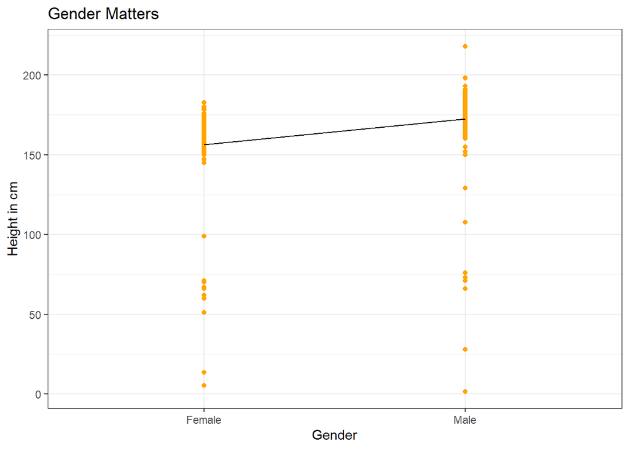

```r
new <- new_high %>% filter(!is.na(Height_cm)) %>%
  filter(Gender == "Male" | Gender == "Female")

ggplot(new, aes(x=Gender, y=Height_cm, group=1)) +
  geom_point(color="orange") +
  stat_summary(fun="mean", geom="line") +
  labs(title="Gender Matters", x="Gender", y="Height in cm") +
  theme_bw()
```

Looking at the graph above we can see that men generally have a higher height than females.

```r
new %>%
  group_by(Gender) %>%
  summarise(`Mean Heights`=mean(Height_cm)) %>%
  pander(caption="Mean Height according to Gender")
```

Mean Height according to Gender

| Gender | Mean Heights |
| --- | --- |
| Female | 156.4 |
| Male | 172.6 |

#### Class Level

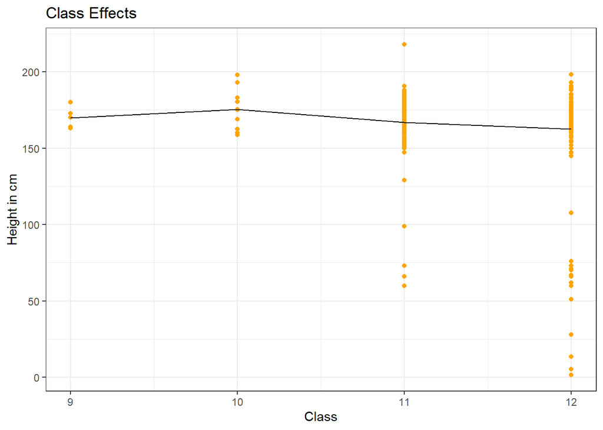

```r
ggplot(new, aes(x=ClassGrade, y=Height_cm, group=1)) +
  geom_point(color="orange") +
  stat_summary(fun="mean", geom="line") +
  labs(title="Class Effects", x="Class", y="Height in cm") +
  theme_bw()
```

It appears that the younger grades have a larger heights as compared to the later grad levels but there is a good chance that this is due to the smaller number of people within the younger grades, there’s a possibility that there is a larger amount of people within the younger grades that are much younger but not show.